# Homework 5

Erik Carlson, Emmanuel Mendez, Emily Vasquez, and Joe Correa

11/2/2020

For this homework, we improve some of our regression models to explain wages.

First we subsetted the data, in this case the subset we used was for individuals who were born in Central America between the ages of 25 and 55, who work at least 40-47 weeks a year, who work 35 hours or more a week.

We also subsetted the same data but we did not subset based on birthplace.

```r
load("acs2017_ny_data.RData")
attach(acs2017_ny)
use_varb <- (AGE >= 25) & (AGE <= 55) & (LABFORCE == 2) & (WKSWORK2 > 4) & (UHRSWORK >= 35) & (BPL == "Central America")
#For our first subset we use people in prime age 25 <= >= age 55, in the labor force and born in central america.
use_varb_non <- (AGE >= 25) & (AGE <= 55) & (LABFORCE == 2) & (WKSWORK2 > 4) & (UHRSWORK >= 35)
dat_use <- subset(acs2017_ny,use_varb)
dat_use_non <- subset(acs2017_ny,use_varb_non)
detach(acs2017_ny)
```

Following subsetting the data we ran a regression of Wage against age, sex and education. Then we calculated the mean age for a 25 year old male with some college, a 25 year old male with a college education and a 35 year old male with an advanced degree. Since this is from our subsetted data, these individuals are form Central America.

```r
reg_biv <- lm(INCWAGE ~ AGE + female + educ_hs + educ_somecoll + educ_college + educ_advdeg, data=dat_use)
summary(reg_biv)
```

```
##
## Call:
## lm(formula = INCWAGE ~ AGE + female + educ_hs + educ_somecoll +
##     educ_college + educ_advdeg, data = dat_use)
##
## Residuals:
## <Labelled double>: Wage and salary income
##    Min     1Q Median     3Q    Max
## -81468 -15273  -5910   6941 611964
##
## Labels:
##   value   label
##  999998 Missing
##  999999     N/A
##
## Coefficients:
##               Estimate Std. Error t value Pr(>|t|)
## (Intercept)    10224.7     8920.0   1.146  0.25208
## AGE              658.6      211.7   3.112  0.00194 **
## female         -8556.5     3789.5  -2.258  0.02426 *
## educ_hs         3800.8     4233.5   0.898  0.36961
## educ_somecoll  11599.5     5763.3   2.013  0.04454 *
## educ_college   29154.8     6249.2   4.665 3.70e-06 ***
## educ_advdeg    69399.5     8706.0   7.971 6.53e-15 ***
## ---
## Signif. codes:  0 '***' 0.001 '**' 0.01 '*' 0.05 '.' 0.1 ' ' 1
##
## Residual standard error: 46450 on 688 degrees of freedom
## Multiple R-squared:  0.1186, Adjusted R-squared:  0.1109
## F-statistic: 15.43 on 6 and 688 DF,  p-value: < 2.2e-16
```

```r
age_25_some_col<- coef(reg_biv)[1] + 25*coef(reg_biv)[2] + coef(reg_biv)[5]
age_25_col<- coef(reg_biv)[1] + 25*coef(reg_biv)[2] + coef(reg_biv)[6]
age_35_adv<- coef(reg_biv)[1] + 35*coef(reg_biv)[2] + coef(reg_biv)[7]

summary(reg_biv)
```

```
##
## Call:
## lm(formula = INCWAGE ~ AGE + female + educ_hs + educ_somecoll +
##     educ_college + educ_advdeg, data = dat_use)
##
## Residuals:
## <Labelled double>: Wage and salary income
##    Min     1Q Median     3Q    Max
## -81468 -15273  -5910   6941 611964
##
## Labels:
##   value   label
##  999998 Missing
##  999999     N/A
##
## Coefficients:
##               Estimate Std. Error t value Pr(>|t|)
## (Intercept)    10224.7     8920.0   1.146  0.25208
## AGE              658.6      211.7   3.112  0.00194 **
## female         -8556.5     3789.5  -2.258  0.02426 *
## educ_hs         3800.8     4233.5   0.898  0.36961
## educ_somecoll  11599.5     5763.3   2.013  0.04454 *
## educ_college   29154.8     6249.2   4.665 3.70e-06 ***
## educ_advdeg    69399.5     8706.0   7.971 6.53e-15 ***
## ---
## Signif. codes:  0 '***' 0.001 '**' 0.01 '*' 0.05 '.' 0.1 ' ' 1
##
## Residual standard error: 46450 on 688 degrees of freedom
## Multiple R-squared:  0.1186, Adjusted R-squared:  0.1109
## F-statistic: 15.43 on 6 and 688 DF,  p-value: < 2.2e-16
```

```r
print("Mean Wage of Age 25 male born in Central America with some college")
```

```
## [1] "Mean Wage of Age 25 male born in Central America with some college"
```

```r
print(age_25_some_col)
```

```
## (Intercept)
##     38289.2
```

```r
print("Mean Wage of Age 25 male born in Central America with a college degree")
```

```
## [1] "Mean Wage of Age 25 male born in Central America with a college degree"
```

```r
print(age_25_col)
```

```
## (Intercept)
##    55844.48
```

```r
print("Mean Wage of Age 35 male born in Central America with an advanced degree")
```

```
## [1] "Mean Wage of Age 35 male born in Central America with an advanced degree"
```

```r
print(age_35_adv)
```

```
## (Intercept)
##    102675.2
```

In this regression the increase in wage from a high school education is not statistically significant, so it is not statistically different from an individual without a high school education. This was compared to the general population by doing the same regression and mean wage calculations using the second subset, in this case the one that did not subset by place of birth.

```r
reg_biv_non <- lm(INCWAGE ~ AGE + female + educ_hs + educ_somecoll + educ_college + educ_advdeg, data=dat_use_non)

age_25_some_col<- coef(reg_biv_non)[1] + 25*coef(reg_biv_non)[2] + coef(reg_biv_non)[5]
age_25_col<- coef(reg_biv_non)[1] + 25*coef(reg_biv_non)[2] + coef(reg_biv_non)[6]
age_35_adv<- coef(reg_biv_non)[1] + 35*coef(reg_biv_non)[2] + coef(reg_biv_non)[7]

summary(reg_biv_non)
```

```
##
## Call:
## lm(formula = INCWAGE ~ AGE + female + educ_hs + educ_somecoll +
##     educ_college + educ_advdeg, data = dat_use_non)
##
## Residuals:
## <Labelled double>: Wage and salary income
##     Min      1Q  Median      3Q     Max
## -146859  -33148  -10757   12908  627834
##
## Labels:
##   value   label
##  999998 Missing
##  999999     N/A
##
## Coefficients:
##                Estimate Std. Error t value Pr(>|t|)
## (Intercept)   -13788.22    2344.93  -5.880 4.13e-09 ***
## AGE             1341.05      39.62  33.850  < 2e-16 ***
## female        -25664.63     719.00 -35.695  < 2e-16 ***
## educ_hs        12856.93    1786.14   7.198 6.19e-13 ***
## educ_somecoll  25300.69    1819.51  13.905  < 2e-16 ***
## educ_college   60817.28    1783.93  34.092  < 2e-16 ***
## educ_advdeg    86890.04    1825.83  47.589  < 2e-16 ***
## ---
## Signif. codes:  0 '***' 0.001 '**' 0.01 '*' 0.05 '.' 0.1 ' ' 1
##
## Residual standard error: 76890 on 46964 degrees of freedom
## Multiple R-squared:  0.1469, Adjusted R-squared:  0.1468
## F-statistic:  1347 on 6 and 46964 DF,  p-value: < 2.2e-16
```

```r
print("Mean Wage of Age 25 year old male with some college")
```

```
## [1] "Mean Wage of Age 25 year old male with some college"
```

```r
print(age_25_some_col)
```

```
## (Intercept)
##    45038.64
```

```r
print("Mean Wage of Age 25 male with a college degree")
```

```
## [1] "Mean Wage of Age 25 male with a college degree"
```

```r
print(age_25_col)
```

```
## (Intercept)
##    80555.23
```

```r
print("Mean Wage of Age 35 male with an advanced degree")
```

```
## [1] "Mean Wage of Age 35 male with an advanced degree"
```

```r
print(age_35_adv)
```

```
## (Intercept)
##    120038.5
```

It is not terribly helpful to compare intercepts and regression coeficcients for these two different regressions. However one can stil judge the significance of the coefficients and compare estimated means for different demographic factors. For example, in this regression that is for the more general populace, a high school education was deemed statistically significant. Furthermore, the mean wages for those born in Central America were lower when compared to their direct equivalent.  
For example, An age 25 year old male with some college born in Central America had an estimated $6749.44 lower wage. An Age 25 male with a college degree born in Central America had an estimated $24710.75 lower wage. An age 35 year old male with an advanced degree born in Central America had an estimated $17363.30 lower wage,

```r
#get rid of?
attach(dat_use)
reg_log <- lm(log1p(INCWAGE) ~ AGE + female + educ_hs + educ_somecoll + educ_college + educ_advdeg)

age_25_some_col_l<- coef(reg_log)[1] + 25*coef(reg_log)[2] + coef(reg_log)[5]
age_25_col_l<- coef(reg_log)[1] + 25*coef(reg_log)[2] + coef(reg_log)[6]
age_35_adv_l<- coef(reg_log)[1] + 35*coef(reg_log)[2] + coef(reg_log)[7]

summary(reg_log)
```

```
##
## Call:
## lm(formula = log1p(INCWAGE) ~ AGE + female + educ_hs + educ_somecoll +
##     educ_college + educ_advdeg)
##
## Residuals:
## <Labelled double>: Wage and salary income
##      Min       1Q   Median       3Q      Max
## -10.6735  -0.0051   0.4327   0.7617   4.1966
##
## Labels:
##   value   label
##  999998 Missing
##  999999     N/A
##
## Coefficients:
##               Estimate Std. Error t value Pr(>|t|)
## (Intercept)    9.13172    0.41343  22.088  < 2e-16 ***
## AGE            0.01930    0.00981   1.968 0.049504 *
## female        -0.67641    0.17564  -3.851 0.000129 ***
## educ_hs        0.34137    0.19622   1.740 0.082348 .
## educ_somecoll  0.43989    0.26712   1.647 0.100059
## educ_college   0.90478    0.28964   3.124 0.001860 **
## educ_advdeg    1.67318    0.40351   4.147  3.8e-05 ***
## ---
## Signif. codes:  0 '***' 0.001 '**' 0.01 '*' 0.05 '.' 0.1 ' ' 1
##
## Residual standard error: 2.153 on 688 degrees of freedom
## Multiple R-squared:  0.05101,    Adjusted R-squared:  0.04274
## F-statistic: 6.164 on 6 and 688 DF,  p-value: 2.602e-06
```

```r
print(age_25_some_col_l)
```

```
## (Intercept)
##    10.05419
```

```r
print(age_25_col_l)
```

```
## (Intercept)
##    10.51908
```

```r
print(age_35_adv_l)
```

```
## (Intercept)
##    11.48051
```

```r
detach(dat_use)
```

A nonlinear regression was done with the data subsetted for those born in Central America with an Age squared component. An assumption of this added component would be that as age increased, Income would peak, plateau then decrease.

In previous lab work it was found that the squared component was significant in the un-subsetted acs data. This is because all ages were included, including the elderly when wage would significantly decrease. It was unknown whether this component would be significant for our subsetted data.

```r
reg_sq <- lm(INCWAGE ~ AGE + I(AGE^2) + female + educ_hs + educ_somecoll + educ_college + educ_advdeg, data=dat_use)
summary(reg_sq)
```

```
##
## Call:
## lm(formula = INCWAGE ~ AGE + I(AGE^2) + female + educ_hs + educ_somecoll +
##     educ_college + educ_advdeg, data = dat_use)
##
## Residuals:
## <Labelled double>: Wage and salary income
##    Min     1Q Median     3Q    Max
## -83747 -16107  -6014   7732 610853
##
## Labels:
##   value   label
##  999998 Missing
##  999999     N/A
##
## Coefficients:
##                Estimate Std. Error t value Pr(>|t|)
## (Intercept)   -31290.46   41223.26  -0.759   0.4481
## AGE             2813.99    2100.22   1.340   0.1807
## I(AGE^2)         -26.89      26.07  -1.032   0.3027
## female         -8867.62    3801.29  -2.333   0.0199 *
## educ_hs         4194.29    4250.47   0.987   0.3241
## educ_somecoll  12293.31    5802.12   2.119   0.0345 *
## educ_college   29722.70    6273.09   4.738 2.62e-06 ***
## educ_advdeg    70002.54    8725.18   8.023 4.46e-15 ***
## ---
## Signif. codes:  0 '***' 0.001 '**' 0.01 '*' 0.05 '.' 0.1 ' ' 1
##
## Residual standard error: 46450 on 687 degrees of freedom
## Multiple R-squared:   0.12,  Adjusted R-squared:  0.111
## F-statistic: 13.38 on 7 and 687 DF,  p-value: 2.998e-16
```

```r
age_25_some_col2<- coef(reg_sq)[1] + 25*coef(reg_sq)[2] + (25**2)*coef(reg_sq)[3] + coef(reg_sq)[6]
print(age_25_some_col2)
```

```
## (Intercept)
##    34546.12
```

From this regression it can be seen from the t value and p value for the age squared coefficient, that it is not statistically significant. This means that the age squared component is not statistically different from zero, therefore it is incorrect to assume this nonlinear model, and that it is more appropriate to model Age linearally.

We wished to determine whether this nonlinear factor of age was significant if we did not subset by birth place.

```r
reg_non_sq <- lm(INCWAGE ~ AGE + I(AGE^2) + female + educ_hs + educ_somecoll + educ_college + educ_advdeg, data=dat_use_non)

reg_non_tri <- lm(INCWAGE ~ AGE + I(AGE^2) + I(AGE^3) + female + educ_hs + educ_somecoll + educ_college + educ_advdeg, data=dat_use_non)


summary(reg_non_sq)
```

```
##
## Call:
## lm(formula = INCWAGE ~ AGE + I(AGE^2) + female + educ_hs + educ_somecoll +
##     educ_college + educ_advdeg, data = dat_use_non)
##
## Residuals:
## <Labelled double>: Wage and salary income
##     Min      1Q  Median      3Q     Max
## -138580  -32977  -10688   13000  623455
##
## Labels:
##   value   label
##  999998 Missing
##  999999     N/A
##
## Coefficients:
##                 Estimate Std. Error t value Pr(>|t|)
## (Intercept)   -1.146e+05  8.101e+03 -14.143  < 2e-16 ***
## AGE            6.580e+03  4.051e+02  16.244  < 2e-16 ***
## I(AGE^2)      -6.499e+01  5.001e+00 -12.995  < 2e-16 ***
## female        -2.536e+04  7.181e+02 -35.317  < 2e-16 ***
## educ_hs        1.348e+04  1.784e+03   7.555 4.25e-14 ***
## educ_somecoll  2.588e+04  1.817e+03  14.244  < 2e-16 ***
## educ_college   6.154e+04  1.782e+03  34.541  < 2e-16 ***
## educ_advdeg    8.663e+04  1.823e+03  47.529  < 2e-16 ***
## ---
## Signif. codes:  0 '***' 0.001 '**' 0.01 '*' 0.05 '.' 0.1 ' ' 1
##
## Residual standard error: 76760 on 46963 degrees of freedom
## Multiple R-squared:  0.1499, Adjusted R-squared:  0.1498
## F-statistic:  1183 on 7 and 46963 DF,  p-value: < 2.2e-16
```

```r
summary(reg_non_tri)
```

```
##
## Call:
## lm(formula = INCWAGE ~ AGE + I(AGE^2) + I(AGE^3) + female + educ_hs +
##     educ_somecoll + educ_college + educ_advdeg, data = dat_use_non)
##
## Residuals:
## <Labelled double>: Wage and salary income
##     Min      1Q  Median      3Q     Max
## -138622  -32984  -10700   12979  623506
##
## Labels:
##   value   label
##  999998 Missing
##  999999     N/A
##
## Coefficients:
##                 Estimate Std. Error t value Pr(>|t|)
## (Intercept)   -1.079e+05  3.838e+04  -2.811  0.00495 **
## AGE            6.047e+03  3.013e+03   2.007  0.04478 *
## I(AGE^2)      -5.133e+01  7.679e+01  -0.669  0.50381
## I(AGE^3)      -1.134e-01  6.359e-01  -0.178  0.85852
## female        -2.536e+04  7.181e+02 -35.317  < 2e-16 ***
## educ_hs        1.348e+04  1.784e+03   7.556 4.23e-14 ***
## educ_somecoll  2.588e+04  1.817e+03  14.245  < 2e-16 ***
## educ_college   6.154e+04  1.782e+03  34.541  < 2e-16 ***
## educ_advdeg    8.664e+04  1.823e+03  47.521  < 2e-16 ***
## ---
## Signif. codes:  0 '***' 0.001 '**' 0.01 '*' 0.05 '.' 0.1 ' ' 1
##
## Residual standard error: 76760 on 46962 degrees of freedom
## Multiple R-squared:  0.1499, Adjusted R-squared:  0.1498
## F-statistic:  1035 on 8 and 46962 DF,  p-value: < 2.2e-16
```

```r
linearHypothesis(reg_non_tri, c("I(AGE^2)=0","I(AGE^3)=0"))
```

```
## Linear hypothesis test
##
## Hypothesis:
## I(AGE^2) = 0
## I(AGE^3) = 0
##
## Model 1: restricted model
## Model 2: INCWAGE ~ AGE + I(AGE^2) + I(AGE^3) + female + educ_hs + educ_somecoll +
##     educ_college + educ_advdeg
##
##   Res.Df        RSS Df  Sum of Sq      F    Pr(>F)
## 1  46964 2.7769e+14
## 2  46962 2.7669e+14  2 9.9511e+11 84.448 < 2.2e-16 ***
## ---
## Signif. codes:  0 '***' 0.001 '**' 0.01 '*' 0.05 '.' 0.1 ' ' 1
```

Following this first regression with just Age squared, this component was statistically significant. Continuing we added the Age cubed component in a new regression, which by itself was deemed not statistically significant.

We then did an F test, testing whether both the coefficients of Age squared and Age cubed were zero. If they were not statistically different from zero, then that would say that it can be described with a linear model instead. WIth an F value of 84.448, it was determined that age is a non-linear component of wage. This is expected because Age squared alone was before deemed statistically significiant.

We plotted both our linear and non-linear regressions for certain parameters.

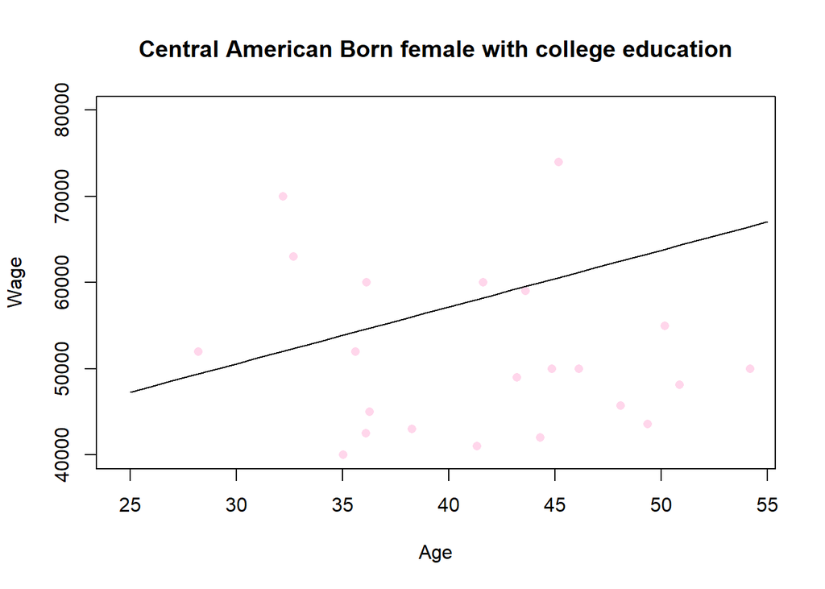

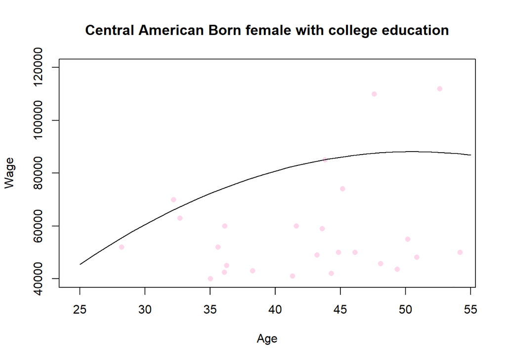

```r
reg_sq <- lm(INCWAGE ~ log(AGE) + I(AGE^2) + female + educ_hs + educ_somecoll + educ_college + educ_advdeg, data=dat_use)

reg_non_sq <- lm(INCWAGE ~ log(AGE) + (AGE^2) + female + educ_hs + educ_somecoll + educ_college + educ_advdeg, data=dat_use_non)

reg_non_tri <- lm(INCWAGE ~ log(AGE) + (AGE^2) + I(AGE^3) + female + educ_hs + educ_somecoll + educ_college + educ_advdeg, data=dat_use_non)

summary(reg_sq)
```

```
##
## Call:
## lm(formula = INCWAGE ~ log(AGE) + I(AGE^2) + female + educ_hs +
##     educ_somecoll + educ_college + educ_advdeg, data = dat_use)
##
## Residuals:
## <Labelled double>: Wage and salary income
##    Min     1Q Median     3Q    Max
## -83757 -16096  -6082   7645 610712
##
## Labels:
##   value   label
##  999998 Missing
##  999999     N/A
##
## Coefficients:
##                 Estimate Std. Error t value Pr(>|t|)
## (Intercept)   -149349.92  125780.39  -1.187   0.2355
## log(AGE)        54941.03   39948.02   1.375   0.1695
## I(AGE^2)           -9.40      12.82  -0.733   0.4637
## female          -8880.61    3801.09  -2.336   0.0198 *
## educ_hs          4206.34    4250.14   0.990   0.3227
## educ_somecoll   12319.54    5801.99   2.123   0.0341 *
## educ_college    29763.58    6274.03   4.744 2.55e-06 ***
## educ_advdeg     69977.06    8722.55   8.023 4.48e-15 ***
## ---
## Signif. codes:  0 '***' 0.001 '**' 0.01 '*' 0.05 '.' 0.1 ' ' 1
##
## Residual standard error: 46450 on 687 degrees of freedom
## Multiple R-squared:  0.1201, Adjusted R-squared:  0.1111
## F-statistic:  13.4 on 7 and 687 DF,  p-value: 2.865e-16
```

```r
summary(reg_non_sq)
```

```
##
## Call:
## lm(formula = INCWAGE ~ log(AGE) + (AGE^2) + female + educ_hs +
##     educ_somecoll + educ_college + educ_advdeg, data = dat_use_non)
##
## Residuals:
## <Labelled double>: Wage and salary income
##     Min      1Q  Median      3Q     Max
## -138654  -33021  -10695   13082  623154
##
## Labels:
##   value   label
##  999998 Missing
##  999999     N/A
##
## Coefficients:
##                Estimate Std. Error t value Pr(>|t|)
## (Intercept)   -518574.4    39541.4 -13.115  < 2e-16 ***
## log(AGE)       191147.5    14946.9  12.788  < 2e-16 ***
## AGE             -3552.3      384.7  -9.234  < 2e-16 ***
## female         -25363.7      718.1 -35.319  < 2e-16 ***
## educ_hs         13448.4     1783.7   7.540 4.79e-14 ***
## educ_somecoll   25840.4     1816.9  14.223  < 2e-16 ***
## educ_college    61508.8     1781.7  34.523  < 2e-16 ***
## educ_advdeg     86566.2     1822.9  47.489  < 2e-16 ***
## ---
## Signif. codes:  0 '***' 0.001 '**' 0.01 '*' 0.05 '.' 0.1 ' ' 1
##
## Residual standard error: 76760 on 46963 degrees of freedom
## Multiple R-squared:  0.1498, Adjusted R-squared:  0.1497
## F-statistic:  1182 on 7 and 46963 DF,  p-value: < 2.2e-16
```

```r
summary(reg_non_tri)
```

```
##
## Call:
## lm(formula = INCWAGE ~ log(AGE) + (AGE^2) + I(AGE^3) + female +
##     educ_hs + educ_somecoll + educ_college + educ_advdeg, data = dat_use_non)
##
## Residuals:
## <Labelled double>: Wage and salary income
##     Min      1Q  Median      3Q     Max
## -138737  -32966  -10758   13004  623612
##
## Labels:
##   value   label
##  999998 Missing
##  999999     N/A
##
## Coefficients:
##                 Estimate Std. Error t value Pr(>|t|)
## (Intercept)   -1.446e+05  1.715e+05  -0.843    0.399
## log(AGE)       2.709e+04  7.472e+04   0.363    0.717
## AGE            2.975e+03  2.938e+03   1.013    0.311
## I(AGE^3)      -4.640e-01  2.071e-01  -2.241    0.025 *
## female        -2.536e+04  7.181e+02 -35.318  < 2e-16 ***
## educ_hs        1.348e+04  1.784e+03   7.557  4.2e-14 ***
## educ_somecoll  2.588e+04  1.817e+03  14.247  < 2e-16 ***
## educ_college   6.154e+04  1.782e+03  34.542  < 2e-16 ***
## educ_advdeg    8.665e+04  1.823e+03  47.527  < 2e-16 ***
## ---
## Signif. codes:  0 '***' 0.001 '**' 0.01 '*' 0.05 '.' 0.1 ' ' 1
##
## Residual standard error: 76760 on 46962 degrees of freedom
## Multiple R-squared:  0.1499, Adjusted R-squared:  0.1498
## F-statistic:  1035 on 8 and 46962 DF,  p-value: < 2.2e-16
```

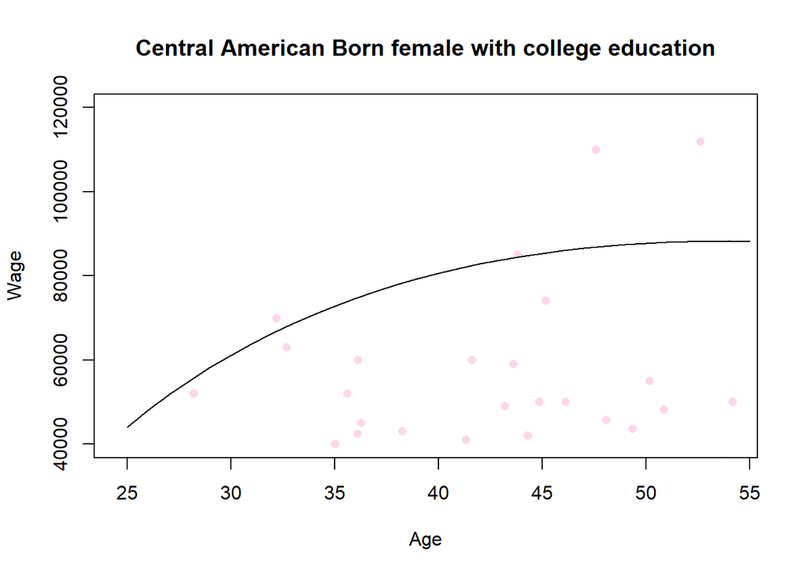

The predicted wage for a central american born female with a college education peaks at 55 years of age. When adding a polynomial to the second degree to the regression, wages peak closer to 50 years of age around 49 years. Once that maximum age is reached, wage decreases as age increases.

As an academic exercise we did a purposely faulty subset regression. In this cause we subset in a manner that included only females with a college education or an advanced degree. We then did a regression that used female and education high school as dependant variables. In this case female would have an NA coefficient because there are only females in the subset, so it would not be compared to anything. Educ_hs would have an NA coefficient because there are no individuals with only a high school education present in the subsetted data.

```
##
## Call:
## lm(formula = INCWAGE ~ AGE + female + educ_hs, data = dat_use2)
##
## Residuals:
## <Labelled double>: Wage and salary income
##    Min     1Q Median     3Q    Max
## -84251 -26802  -7743  16431 571873
##
## Labels:
##   value   label
##  999998 Missing
##  999999     N/A
##
## Coefficients: (2 not defined because of singularities)
##             Estimate Std. Error t value Pr(>|t|)
## (Intercept)  36783.8     7009.3   5.248 1.84e-07 ***
## AGE            863.0      179.2   4.815 1.67e-06 ***
## female            NA         NA      NA       NA
## educ_hs           NA         NA      NA       NA
## ---
## Signif. codes:  0 '***' 0.001 '**' 0.01 '*' 0.05 '.' 0.1 ' ' 1
##
## Residual standard error: 53390 on 1134 degrees of freedom
## Multiple R-squared:  0.02003,    Adjusted R-squared:  0.01917
## F-statistic: 23.18 on 1 and 1134 DF,  p-value: 1.671e-06
```

As expected this regression produced NA values in the areas predicted.

```
## [1] "Log dependant variable:"
```

```
##
## Call:
## lm(formula = log1p(INCWAGE) ~ AGE + I(AGE^2) + female + educ_hs +
##     educ_somecoll + educ_college + educ_advdeg, data = dat_use)
##
## Residuals:
## <Labelled double>: Wage and salary income
##      Min       1Q   Median       3Q      Max
## -10.6038  -0.0119   0.3968   0.7767   4.2828
##
## Labels:
##   value   label
##  999998 Missing
##  999999     N/A
##
## Coefficients:
##                Estimate Std. Error t value Pr(>|t|)
## (Intercept)   12.356650   1.907966   6.476 1.79e-10 ***
## AGE           -0.148129   0.097206  -1.524 0.128003
## I(AGE^2)       0.002089   0.001207   1.731 0.083855 .
## female        -0.652236   0.175938  -3.707 0.000226 ***
## educ_hs        0.310809   0.196727   1.580 0.114591
## educ_somecoll  0.385992   0.268544   1.437 0.151073
## educ_college   0.860667   0.290342   2.964 0.003139 **
## educ_advdeg    1.626336   0.403834   4.027 6.27e-05 ***
## ---
## Signif. codes:  0 '***' 0.001 '**' 0.01 '*' 0.05 '.' 0.1 ' ' 1
##
## Residual standard error: 2.15 on 687 degrees of freedom
## Multiple R-squared:  0.05514,    Adjusted R-squared:  0.04551
## F-statistic: 5.727 on 7 and 687 DF,  p-value: 1.867e-06
```

```
## [1] "The wage of a 25 year old male from our subset with some college education is:"
```

[output not shown]

```
## [1] "The wage of a 35 year old male from our subset with some college education is:"
```

```
## (Intercept)
##    24759.75
```

```
## [1] "The wage of a 45 year old male from our subset with some college education is:"
```

```
## (Intercept)
##    29934.49
```

```
## [1] "The wage of a 45 year old female from our subset with some college education is:"
```

```
## (Intercept)
##    15592.27
```

```
## [1] "Non-log dependant variable:"
```

```
##
## Call:
## lm(formula = INCWAGE ~ AGE + I(AGE^2) + female + educ_hs + educ_somecoll +
##     educ_college + educ_advdeg, data = dat_use)
##
## Residuals:
## <Labelled double>: Wage and salary income
##    Min     1Q Median     3Q    Max
## -83747 -16107  -6014   7732 610853
##
## Labels:
##   value   label
##  999998 Missing
##  999999     N/A
##
## Coefficients:
##                Estimate Std. Error t value Pr(>|t|)
## (Intercept)   -31290.46   41223.26  -0.759   0.4481
## AGE             2813.99    2100.22   1.340   0.1807
## I(AGE^2)         -26.89      26.07  -1.032   0.3027
## female         -8867.62    3801.29  -2.333   0.0199 *
## educ_hs         4194.29    4250.47   0.987   0.3241
## educ_somecoll  12293.31    5802.12   2.119   0.0345 *
## educ_college   29722.70    6273.09   4.738 2.62e-06 ***
## educ_advdeg    70002.54    8725.18   8.023 4.46e-15 ***
## ---
## Signif. codes:  0 '***' 0.001 '**' 0.01 '*' 0.05 '.' 0.1 ' ' 1
##
## Residual standard error: 46450 on 687 degrees of freedom
## Multiple R-squared:   0.12,  Adjusted R-squared:  0.111
## F-statistic: 13.38 on 7 and 687 DF,  p-value: 2.998e-16
```

```
## [1] "The wage of a 25 year old male from our subset with some college education is:"
```

```
## (Intercept)
##    34546.12
```

```
## [1] "The wage of a 35 year old male from our subset with some college education is:"
```

```
## (Intercept)
##    46551.86
```

```
## [1] "The wage of a 45 year old male from our subset with some college education is:"
```

```
## (Intercept)
##    53179.55
```

```
## [1] "The wage of a 45 year old female from our subset with some college education is:"
```

```
## (Intercept)
##    44311.93
```

Interestingly when taking the log of wage as the dependent variable, the sign of AGE changed from positive to negative. When comparing it to the non log regression of the same independent variables, we get AGE as a positive value. This could be due multicollinearity leading to a strong relationship between wage and age at all age levels.

A question posed in the lab was whether it made sense to include squared non-linear components of dummy variables. In this case it would not be appropriate and not make much sense. The values of dummy variables are 0 or 1 (True of False) therefore raising the dummy’s to a power will not change the answers. So, Beta * 1^2, is not appropriate to put in a regression.

We then did a regression with interactions between dependant variables. In this case we used female, various races, and then interactions between female and those races. This would inform us of the effects on wage for being a female with races.

```r
reg_test <- lm(INCWAGE ~ AGE + female + I(female*AfAm) + I(female*Hispanic) + I(female*Asian) + I(female*race_oth) + AfAm + Hispanic + Asian + race_oth  , data=dat_use_non )
summary(reg_test)
```

```
##
## Call:
## lm(formula = INCWAGE ~ AGE + female + I(female * AfAm) + I(female *
##     Hispanic) + I(female * Asian) + I(female * race_oth) + AfAm +
##     Hispanic + Asian + race_oth, data = dat_use_non)
##
## Residuals:
## <Labelled double>: Wage and salary income
##     Min      1Q  Median      3Q     Max
## -102599  -37895  -15873   12778  611200
##
## Labels:
##   value   label
##  999998 Missing
##  999999     N/A
##
## Coefficients:
##                       Estimate Std. Error t value Pr(>|t|)
## (Intercept)           50601.15    1807.19  28.000  < 2e-16 ***
## AGE                     945.41      41.53  22.762  < 2e-16 ***
## female               -23109.44     933.97 -24.743  < 2e-16 ***
## I(female * AfAm)      16190.92    2393.62   6.764 1.36e-11 ***
## I(female * Hispanic)  14405.90    2463.25   5.848 5.00e-09 ***
## I(female * Asian)     10414.64    2913.38   3.575 0.000351 ***
## I(female * race_oth)   3449.70    2707.48   1.274 0.202622
## AfAm                 -29409.74    1750.15 -16.804  < 2e-16 ***
## Hispanic             -24644.07    1666.78 -14.785  < 2e-16 ***
## Asian                   682.79    1948.88   0.350 0.726079
## race_oth             -12772.99    1822.25  -7.009 2.42e-12 ***
## ---
## Signif. codes:  0 '***' 0.001 '**' 0.01 '*' 0.05 '.' 0.1 ' ' 1
##
## Residual standard error: 81500 on 46960 degrees of freedom
## Multiple R-squared:  0.04181,    Adjusted R-squared:  0.04161
## F-statistic: 204.9 on 10 and 46960 DF,  p-value: < 2.2e-16
```

Being female is a negative factor on income, however the differential between females and males of African American, Hispanic, and Asian descent is lower compared with individuals not of those races. For example, the coefficient of female shows a decrease in wage of 23109.44 dollars. However Female*Afam is 16190.92, so it can be thought that the difference between male and female african americans is -23109.44 + 16190.92, or only a gender gap of -6918.52.

Following this a regression was conducted with INCWAGE being the independant variable to predict Age for out subsetted group.

```r
rev_reg <- lm(AGE ~ INCWAGE, data=dat_use)
summary(rev_reg)
```

```
##
## Call:
## lm(formula = AGE ~ INCWAGE, data = dat_use)
##
## Residuals:
##      Min       1Q   Median       3Q      Max
## -16.2753  -6.3965   0.3822   6.8410  15.0267
##
## Coefficients:
##              Estimate Std. Error t value Pr(>|t|)
## (Intercept) 3.978e+01  4.219e-01  94.286   <2e-16 ***
## INCWAGE     1.959e-05  6.429e-06   3.047   0.0024 **
## ---
## Signif. codes:  0 '***' 0.001 '**' 0.01 '*' 0.05 '.' 0.1 ' ' 1
##
## Residual standard error: 8.344 on 693 degrees of freedom
## Multiple R-squared:  0.01322,    Adjusted R-squared:  0.01179
## F-statistic: 9.283 on 1 and 693 DF,  p-value: 0.002401
```

In this case the R-squared value is significantly lower than when we used age and other factors to help predict Income. A variable may be a predictor of another, but it is not necessarily the case that the reverse is also a good predictor.